# WYBORY - Podsumowanie

#### Emilia Momotko, Paweł Grabowski, Martyna Śpiewak

## Źródła

Dane zbieraliśmy z trzech głównych źródeł:

- **portale informacyjne** - tvpinfo.pl, wp.pl, wprost.pl, onet.pl, newsweek.pl, tvn24.pl, naTemat.pl, gazeta.pl, dziennik.pl, wyborcza.pl;
- **Twitter** - tweety z oficjalnych profili kandydatow;
- **Facebook** - posty publikowane na publicznych stronach kandtydatów.

## Wskaźniki

Na podstawie poniższych wskaźników analizowaliśmy zebrane dane:

- **portale informacyjne**
  - **candidate_fraction_info** - czestotliowść artykułóW o danym kandydacie na prezydenta względem wszystkich artykułóW zwiaznych z wyborami (dla kazdego z 10 kandydatów), wkaźnik jest wyliczany dla każdej strony: TvPInfo, Wp.Pl, Wprost.Pl, Onet.Pl, Newsweek.Pl, Tvn24.Pl, Natemat.Pl, Gazeta.Pl, Dziennik.Pl oraz Wyborcza.Pl;
  - **candidate_general_info** - liczba artykółów, która ukazała się na temat danego kandydata dla każdej ze stron wymienionych powyżej;
  - z **candidate_position** związane są dwa wskaźniki **position** - uwzględnia miejsce na stronie głównej portalu informacyjnego, na której ukazał się artykuł: skala od 1 do 4, 1 - główny artykuł na stronie, 2 - artykuł pod głównym artykułem, 3 - artykuły w lewej lub prawej stopce, 4 - inne miejsce na stronie, kolejny wskaźnik to **fontSize** to rozmiar czcionki tytułu artykułu.
- **Twitter**
  - **sentyment** - określa poziom wydźwięku tweetów na temat kandydatów na prezydenta, na podstawie zbudowanych słownikow `pozytywne` i `negatywne` ocenialiśmy sentyment tychże wiadomości. Jeżeli różnica między liczbą słóW pozytywnych a liczbą słóW negatywnych w danym tweecie była równa -1, 0, 1 - taką wiadomość uznawaliśmy za neutralną, jeśli różnica była większa od 1 - tweet pozytywny, natomiast roznica mniejsza od -1 - tweet o negatywnym wydźwięku.
  - Pozostałe wskaźniki są związane z oficjalnymi profilami kandydatów na Twitterze. Badamy kolejno **liczba tweetow**, **srednio retweetow**, **suma retweetow**, **suma likeow**, **srednio likeow**
- **Facebook**
  - **like_w_czasie** - liczba polubień strony odnotowana każdego dnia pobierania danych. Jako, że dla każdego kandydata zbierane są dane z kilku fanpejdży, dla każdego z nich zwracana jest liczba polubień. Z tym wskaźnikiem jest ściśle związany wskaźnik **like_najlepszy_wynik**, który jednoznacznie wskazuje na najwyższą liczbę polubień wybraną ze wszystkim dostępnych stron dla wybranego kandydata.
  - **like_roznice_w_czasie** - przyrost liczby polubien miedzy kolejnymi dniami
  - **post_ile_dziennie** - funkcja o tej nazwie zwraca **4** następujące wskaźniki: suma wszystkich postów opublikowana na każdej stronie w ciagu jednego dnia, średnia liczba polubień opublikowanych postów, średnia liczba komentarzy do postów oraz średnia liczba udostępnień tych postów;
  - **wordcloud** - czestotliwość pojawiania się słów w publikowanych postach na stronach na temat kandydatów w podanym odcinku czasowym.

## Analiza

### Portale infromacyjne

Aby zobaczyć wykresy zapraszamy do aplikacji Shiny.

### Twitter

Na początku sprawdźmy jak wyglądał wydźwięk tweetów publikowanych twitter.com na temat kandydatów na prezydenta.

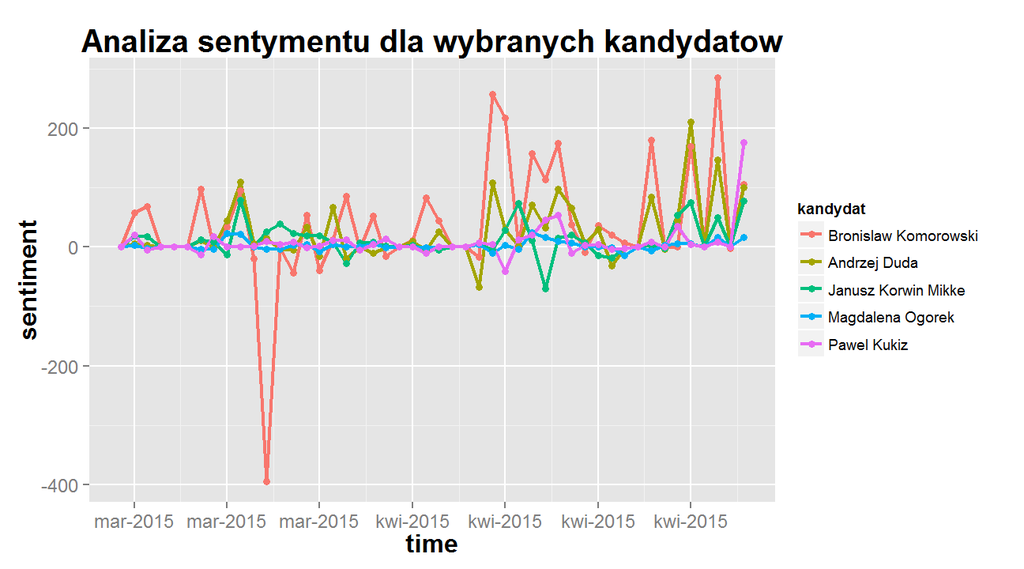

Poniższy wykres przedstawia liczbę tweetów, które zostały opublikowane na oficjalnych stronach kandydatów na prezydenta na stronie twitter.com.

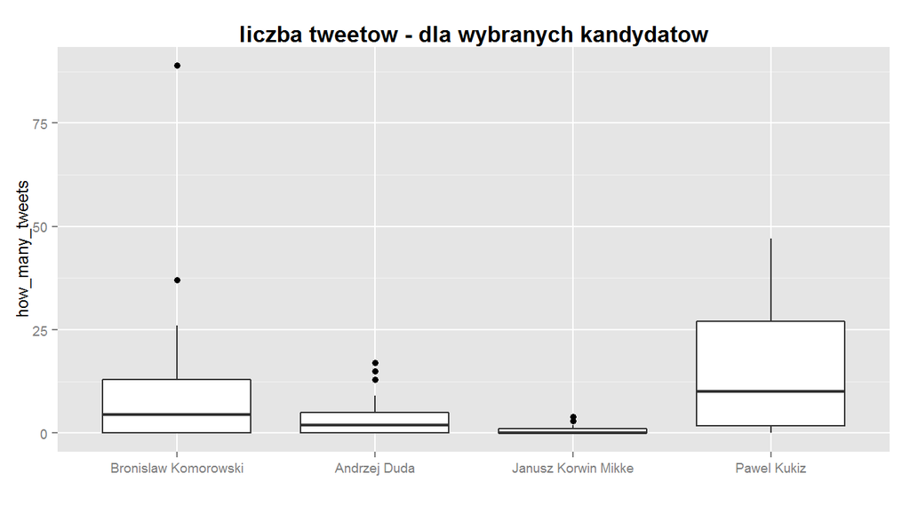

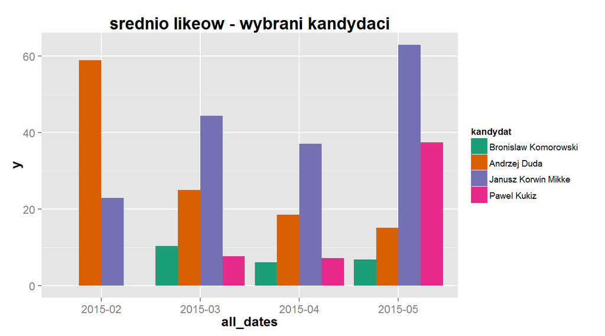

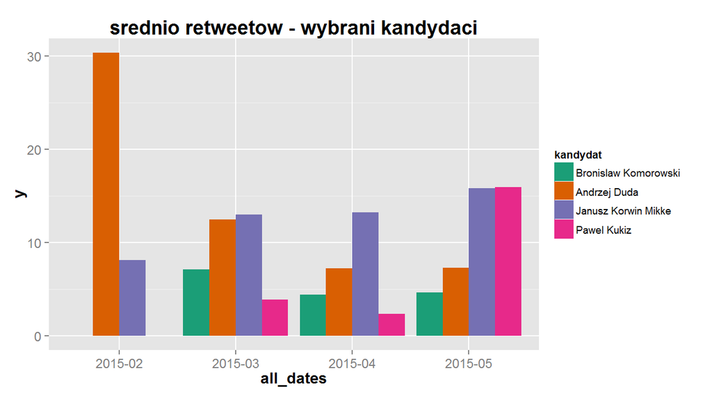

### Facebook

Na początku sprawdźmy, który z kandydantów odnotował największą liczbę polubień na facebook.com.

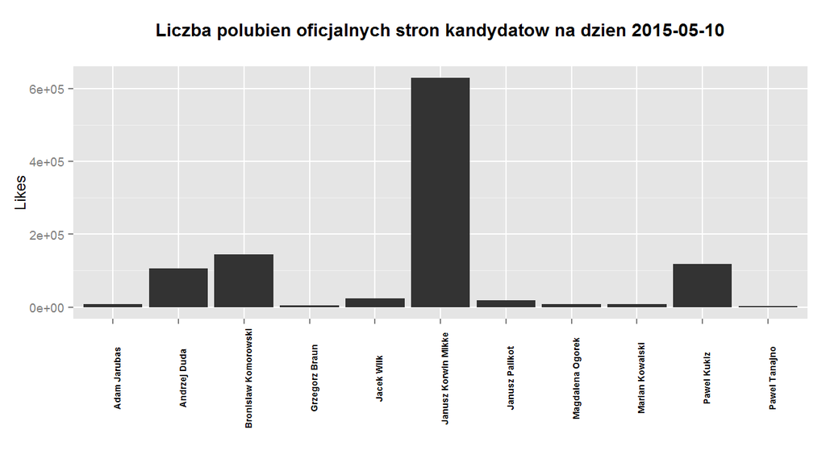

Dokładne wyniki dla TOP5 wyglądają następująco:

```
##                   name  likes
## 1  Janusz Korwin Mikke 629177
## 2 Bronislaw Komorowski 144244
## 3          Pawel Kukiz 119073
## 4         Andrzej Duda 105244
## 5           Jacek Wilk  23465
```

Następnie sprawdźmy jak zmieniała się liczba polubień oficjalnych stron kandydatów w czasie. Do porównania wybraliśmy kandydatów, którzy w pierwszej turze wyborów otrzymali 5 najlepszych wyników, tj. Andrzej Duda, Bronisław Komorowski, Paweł Kukiz, Janusz Korwin Mikke oraz Magdalena Ogorek.

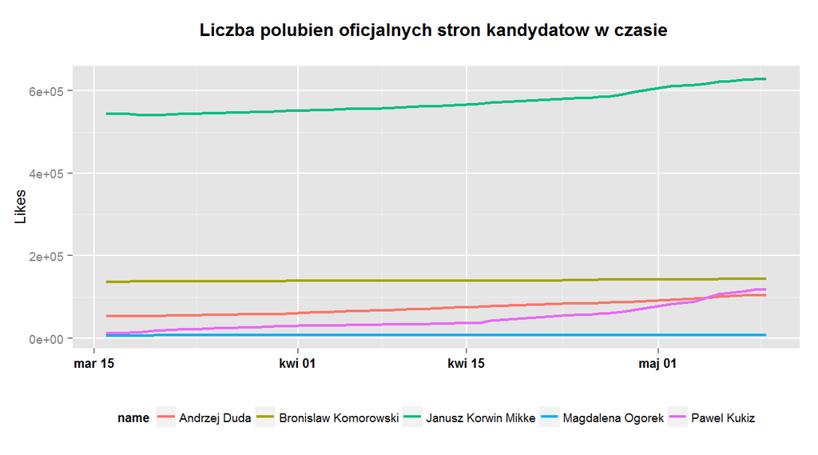

Widać ogromną różnicę między Januszem Korwinem - Mikke a pozostałymi kandydatami, sprawdźmy jak wygląda wykres po usunięciu ze zbioru obserwacji danych dotyczących Janusza Korwina - Mikke.

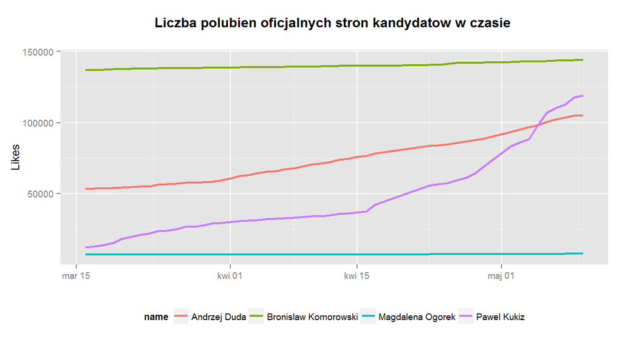

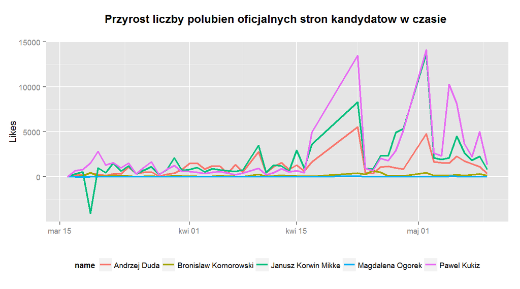

Teraz sprawdźmy jak zmieniały się w czasie wskaźniki związane z samymi artykułami, tj. liczba postów zamieszczana na stronach w ciągu jednego dnia, średnia liczba polubień zamieszczonych postów oraz średnia liczba komentarzy i udostępnień.

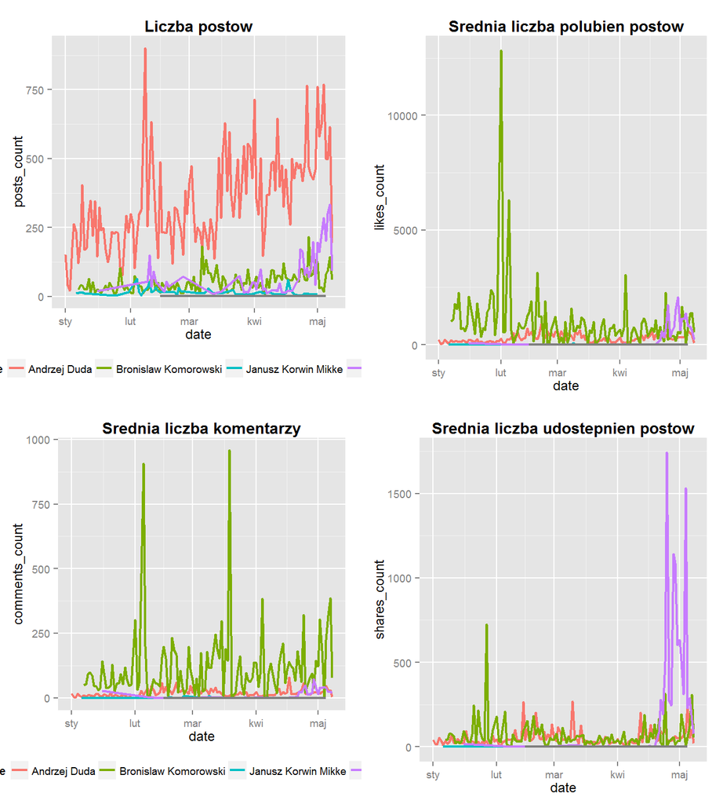

Na koniec sprawdźmy, jakie słowa pojawiały się najczęściej w postach publikowanych na stronach kandydatów tak jak poprzednio, sprawdźmy wyniki dla Andrzeja Dudy, Bronisława Komorowskiego, Pawła Kukiza oraz Janusza Korwina-Mikke.

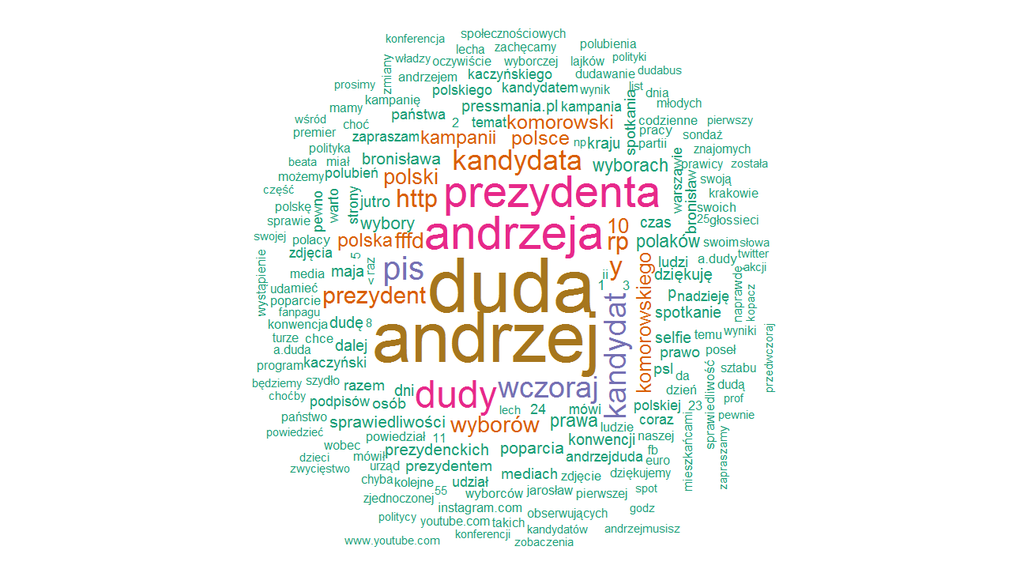

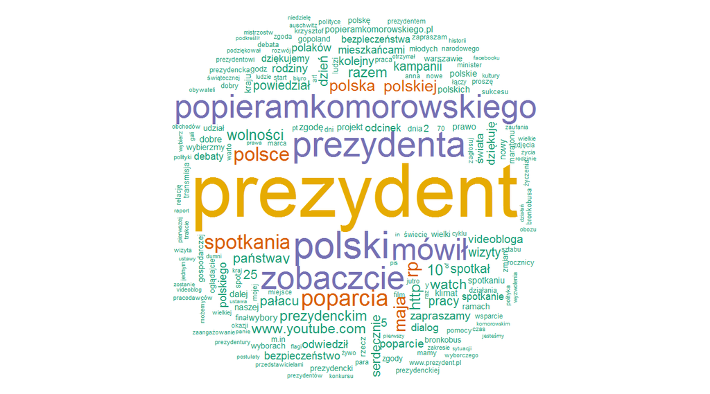

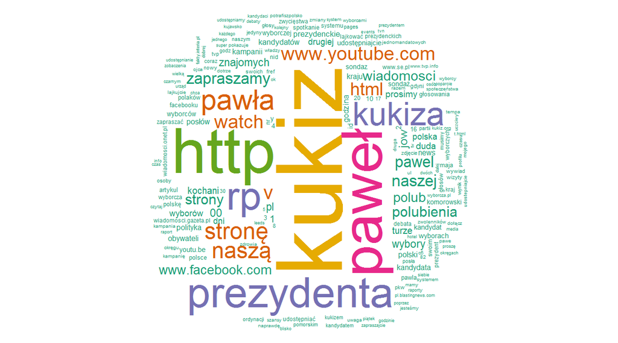

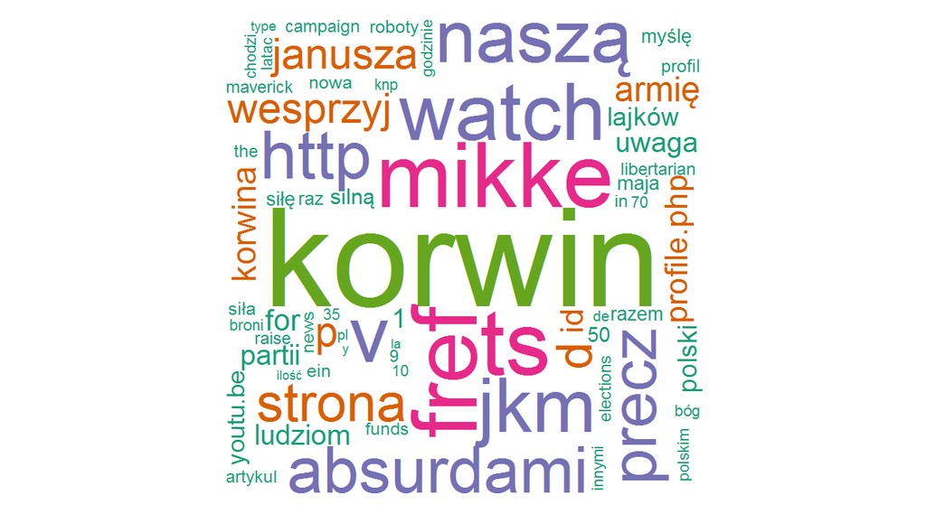

## Podsumowanie

Dane były pobierane między **16-03-2015** a **10-05-2015**. W przeciągu tego czasu udało nam się zebrać

- **3.84 MB** z portali informacyjnych
- **626 MB** z twtiter.com
- **133 MB** z facebook.com

Łącznie: **763 MB**

Ponadto wszystkie wyniki dla każdego z kandydatów można analizować dzięki stworzonej aplikacji Shiny.